# Big Data Overview

Brian Gulbis and Jennifer Gass  
August 17, 2016

### Why Are We Here?

- Feedback from previous residents
- Wanted to learn more about performing statistical analysis on research data

### It's Not So Simple...

| Before You Can… | You Need To… |
| --- | --- |
| Perform statistical analysis | Understand your data |
| Understand your data | Explore and visualize your data |
| Explore and visualize your data | Have clean data to work with |
| Have clean data to work with | Tidy raw data through transformation and aggregation |
| Tidy raw data through transformation and aggregation | Collect some data |
| Collect some data | Find a source of data |
| Find a source of data | Have a research question you are trying answer |

### Data Project Process

[Grolemund G, Wickham H. R for Data Science](http://r4ds.had.co.nz/)

### Overview of Data Series

- Big Data Overview
- Data Storage and Implications
- Collecting Data Efficiently
- Organizing Data for Analysis
- Data Analysis and Statistics
- Visualizing and Reporting Data

### Objectives for Today

- Define big data
- Describe how big data is important within healthcare
- Determine where to get big data
- Identify potential issues with big (and little) data

### Big Data

- Describes the large volume of data (both structured and unstructured) which is available to businesses on a daily basis
- Can be analyzed to make better and more strategic decsisions
  - Cost reductions
  - Time reductions
  - New or optimized products and services
  - Smarter decision making

[SAS](http://www.sas.com/en_us/insights/big-data/what-is-big-data.html)

### Big Data in Healthcare

- Amount of medical data is expected to double every 73 days by 2020
- 80% of health data is unstructured
- Most data is siloed in individual EMR systems

[IBM](http://www.ibm.com/smarterplanet/us/en/ibmwatson/health/)

### Uses of Big Data

- Preventative medicine
  - Combine data from multiple sources to create predictive models
    - Fitness trackers, medical and insurance records, genetic data, etc.
- Clinical trials
  - Data often kept in silos
    - 96% of potentially available data on cancer patients has not been analyzed
  - Data sharing will allow for new discoveries which otherwise would not be apparent

[Forbes](http://www.forbes.com/sites/bernardmarr/2015/04/21/how-big-data-is-changing-healthcare/#ee268ec32d91)

### Data Sharing

[figure not shown]

*N Engl J Med* 2016;374(25)

[figure not shown]

*N Engl J Med* 2016;375(5)

### Uses of Big Data

- Personalized medicine
  - Tailor medicine to an individuals genetic makeup
- Preventing spread of epidemics
  - Mobile phone location data used to track population movements

[Forbes](http://www.forbes.com/sites/bernardmarr/2015/04/21/how-big-data-is-changing-healthcare/#ee268ec32d91)

### Big Data at SCCM

Iwashyna, TJ. Big Data. SCCM Annual Congress 2016

### How is this relevant to me?

- Like it or not, big data is going to significantly impact your career
  - Patient care
  - Research
  - Career opportunities

### Patient Care - New Discoveries

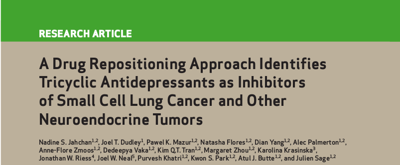

*Cancer Discov* 2013;3:1364

### Patient Care - Prevention and Faster Diagnosis

- IBM Watson Health
  - Technology platform that uses natural language processing and machine learning to reveal insights from large amounts of unstructured data
  - Can read and analyze large amounts of medical records and literature
    - 40 million documents in 15 seconds
  - Improve clinicians ability to diagnose and treat conditions
    - Oncology
    - Preventative care for chronic conditions

[IBM](http://www.ibm.com/smarterplanet/us/en/ibmwatson/health/)

### Research - Big Data Articles on PubMed

> Number of pubs looking at [#BigData](https://twitter.com/hashtag/BigData?src=hash) & [#Health](https://twitter.com/hashtag/Health?src=hash) on [#PubMed](https://twitter.com/hashtag/PubMed?src=hash) are sky-rocketing [#MadeWithR](https://twitter.com/hashtag/MadeWithR?src=hash) [#rstats](https://twitter.com/hashtag/rstats?src=hash) [pic.twitter.com/BDNLVPigx1](https://t.co/BDNLVPigx1)

> — Matt Crowson (@DrMattCrowson) [August 4, 2016](https://twitter.com/DrMattCrowson/status/761006072698118144)

### Research - Ways to Utilize Big Data

1. New sources of data for traditional analysis
2. Identify new causal relationships
3. New analytical methods (i.e., machine learning)
4. Integration of clinical information with operations and research

Iwashyna, TJ. Big Data. SCCM Annual Congress 2016

### Career Opportunities

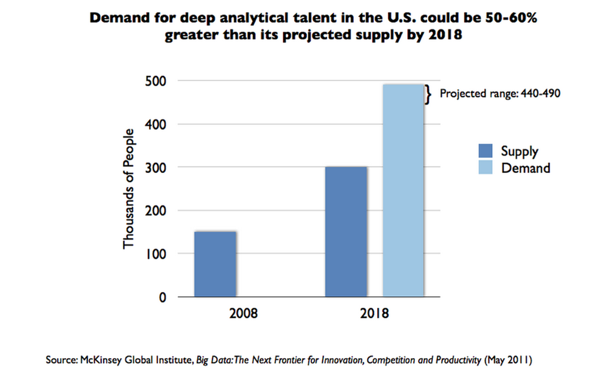

### Data Science Skills are Valuable

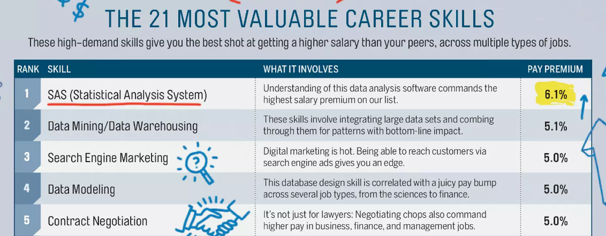

MONEY and PayScale.com. Published in June 2016 MONEY magazine

### What is a Data Scientist?

[Drew Conway](http://drewconway.com/zia/2013/3/26/the-data-science-venn-diagram)

### But I'm a Pharmacy Resident...

- If desired, you can put yourself in a unique position to take advantage of the growing need for people with analytical abilities
  - Have substantive expertise
  - Have (at least some) math and statistics knowledge
  - “Hacking” skills can be learned

### But I'm a Pharmacy Resident...

- If desired, you can put yourself in a unique position to take advantage of the growing need for people with analytical abilities
  - Have substantive expertise
  - Have (at least some) math and statistics knowledge
  - “Hacking” skills can be learned

### So Big Data is Important...

- Data is the second most important thing in research
- The question being asked is the first
- Data may limit or enable certain questions
- It does not matter how much data you have if you are not asking the right question

[The Data Scientist's Toolbox - Coursera](https://www.coursera.org/learn/data-scientists-tools)

### Sources of Data

- Hospital / System Databases
  - Care4, Sovera (manual)
  - EDW, TheraDoc, Cardinal DCOA
- National Organizations
  - UHC/Vizient Clinical Data Base / Resource Manager
  - STS National Database
  - SCCM Critical Care Registry (pending)
- State / Federal Agencies
  - US government
    - https://www.data.gov
    - https://www.healthdata.gov
  - CMS
    - Hospital Compare
  - CDC
    - NHANES
    - https://data.cdc.gov

### Problems with Big Data

- Having all of this data is great!
  - Allows for studies with much larger scopes to be completed in reasonable time frames
  - Identify new causal relationships
  - Develop predictive models using machine learning
- Unfortunately, **data rarely comes “ready-to-use”**

### Fundamental Problem of Observational Data Analysis I

Iwashyna, TJ. Big Data. SCCM Annual Congress 2016

### What You Want...

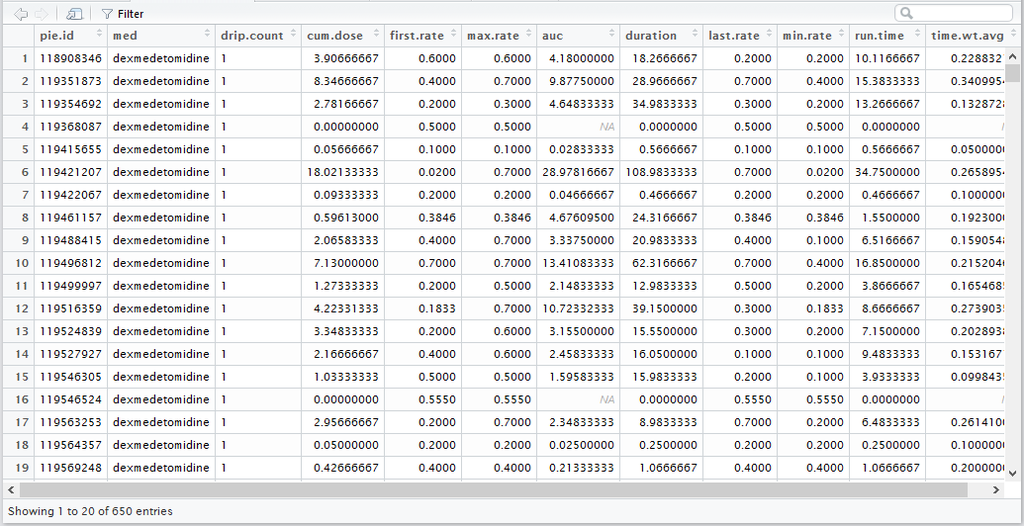

### What You Usually Get...

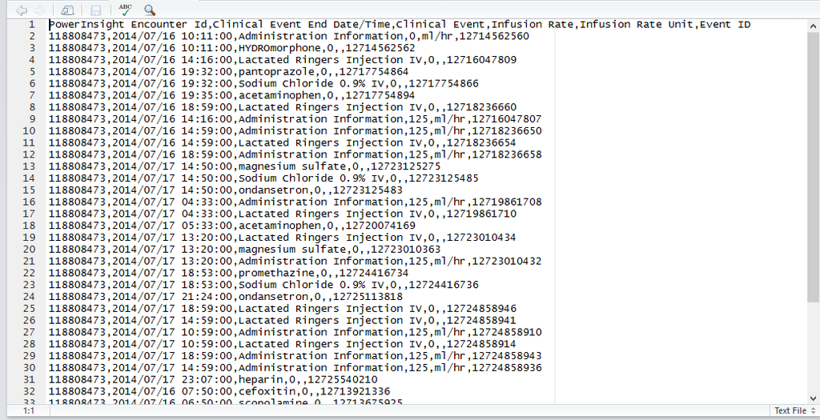

### Getting There...

- Understanding the structure of your data is **essential**
- Almost every data set is going to require some amount of preparation prior to being analyzed
- Preparing the data requires some technical know-how and additional tools
- “Hacking” skills

### Data Preparation

- Estimated that 80% of data analysis is spent on cleaning and preparing data
- **Major limiting factor for most “amateur” researchers**
- Adequately preparing data will facilitate data analysis
  - Allows data to be input into various anlaysis tools
  - Some analysis cannot be performed without cleaning or transforming raw data

Dasu T, Johnson T (2003). Exploratory Data Mining and Data Cleaning. Wiley-IEEE.

### Data Processing Tools

- Basic
  - Spreadsheets (Microsoft Excel, Google Sheets, etc.)
- Intermediate
  - Advanced spreadsheet functions
  - Databases (Microsoft Access, MySQL, etc.)
- Advanced
  - Commerical software (SAS, SPSS, Stata, etc.)
  - Open-source software (R, Python, Julia, etc.)

### Fundamental Problem of Observational Data Analysis II

Iwashyna, TJ. Big Data. SCCM Annual Congress 2016

### Summary

- Big data is here and it's not going away
- Big data is changing
  - The way patients are cared for
  - The way research is conducted
- Big data is a big opportunity for those who want to take advantage of it

### Now, Let's Go Find Some Big Data

- https://www.data.gov
- https://www.healthdata.gov
- https://data.cdc.gov